# Exploratory Data & Business Analysis

The **Data Science Lifecycle** includes steps to perform Exploratory Data Analysis as well as evaluate the outputs of machine learning models. Since most data science projects in industry are set to solve specific business objectives, it's important to evaluate the business impact of the models we build.

### Exploratory Data Analysis (EDA)

[Exploratory Data Analysis](https://en.wikipedia.org/wiki/Exploratory_data_analysis) is the process of analyzing data to derive insights, often done using visualizations. While this process can be done manually, there are a variety of open source tools which can come in handy. We will explore the usage of pandas-profiling below.

**Note:** All required Python packages required for this course are installed via `conda`. Please refer to environment.yml for a detailed list of packages & versions used in this course.

```python
import pandas as pd
import pandas_profiling
import numpy as np
```

```python
airlines_df = pd.read_csv("../data/external/allyears2k.csv", encoding="ISO-8859-1", low_memory=False)
target = "IsDepDelayed"
print("Dataset has {} entries and {} features".format(*airlines_df.shape))

# preview data
airlines_df.head()
```

```
Dataset has 43978 entries and 31 features
```

|  | Year | Month | DayofMonth | DayOfWeek | DepTime | CRSDepTime | ArrTime | CRSArrTime | UniqueCarrier | FlightNum | ... | Cancelled | CancellationCode | Diverted | CarrierDelay | WeatherDelay | NASDelay | SecurityDelay | LateAircraftDelay | IsArrDelayed | IsDepDelayed |
| --- | --- | --- | --- | --- | --- | --- | --- | --- | --- | --- | --- | --- | --- | --- | --- | --- | --- | --- | --- | --- | --- |
| 0 | 1987 | 10 | 14 | 3 | 741.0 | 730 | 912.0 | 849 | PS | 1451 | ... | 0 | NaN | 0 | NaN | NaN | NaN | NaN | NaN | YES | YES |
| 1 | 1987 | 10 | 15 | 4 | 729.0 | 730 | 903.0 | 849 | PS | 1451 | ... | 0 | NaN | 0 | NaN | NaN | NaN | NaN | NaN | YES | NO |
| 2 | 1987 | 10 | 17 | 6 | 741.0 | 730 | 918.0 | 849 | PS | 1451 | ... | 0 | NaN | 0 | NaN | NaN | NaN | NaN | NaN | YES | YES |
| 3 | 1987 | 10 | 18 | 7 | 729.0 | 730 | 847.0 | 849 | PS | 1451 | ... | 0 | NaN | 0 | NaN | NaN | NaN | NaN | NaN | NO | NO |
| 4 | 1987 | 10 | 19 | 1 | 749.0 | 730 | 922.0 | 849 | PS | 1451 | ... | 0 | NaN | 0 | NaN | NaN | NaN | NaN | NaN | YES | YES |

5 rows × 31 columns

`pandas-profiling` can automatically generate a report with the following features:

- Essentials: type, unique values, missing values
- Quantile statistics like minimum value, Q1, median, Q3, maximum, range, interquartile range
- Descriptive statistics like mean, mode, standard deviation, sum, median absolute deviation, coefficient of variation, kurtosis, skewness
- Most frequent values
- Histograms
- Correlations highlighting of highly correlated variables, Spearman and Pearson matrixes

Here's how...

Overview

Dataset info

| Number of variables | 31 |
| --- | --- |
| Number of observations | 43978 |
| Total Missing (%) | 20.0% |
| Total size in memory | 10.4 MiB |
| Average record size in memory | 248.0 B |

Variables types

| Numeric | 17 |
| --- | --- |
| Categorical | 7 |
| Boolean | 3 |
| Date | 0 |
| Text (Unique) | 0 |
| Rejected | 4 |
| Unsupported | 0 |

Warnings

- `ActualElapsedTime` has 1195 / 2.7% missing values Missing

- `AirTime` is highly correlated with `CRSElapsedTime` (ρ = 0.98769) Rejected

- `ArrDelay` has 1514 / 3.4% zeros Zeros

- `ArrDelay` has 1195 / 2.7% missing values Missing

- `ArrTime` has 1195 / 2.7% missing values Missing

- `CRSArrTime` has 569 / 1.3% zeros Zeros

- `CRSDepTime` is highly correlated with `DepTime` (ρ = 0.91498) Rejected

- `CRSElapsedTime` is highly correlated with `ActualElapsedTime` (ρ = 0.98409) Rejected

- `CancellationCode` has 43757 / 99.5% missing values Missing

- `CarrierDelay` has 7344 / 16.7% zeros Zeros

- `CarrierDelay` has 35045 / 79.7% missing values Missing

- `DepDelay` has 6393 / 14.5% zeros Zeros

- `DepDelay` has 1086 / 2.5% missing values Missing

- `DepTime` has 1086 / 2.5% missing values Missing

- `Dest` has a high cardinality: 134 distinct values Warning

- `Distance` is highly correlated with `AirTime` (ρ = 0.97816) Rejected

- `LateAircraftDelay` has 7140 / 16.2% zeros Zeros

- `LateAircraftDelay` has 35045 / 79.7% missing values Missing

- `NASDelay` has 7388 / 16.8% zeros Zeros

- `NASDelay` has 35045 / 79.7% missing values Missing

- `Origin` has a high cardinality: 132 distinct values Warning

- `SecurityDelay` has 8914 / 20.3% zeros Zeros

- `SecurityDelay` is highly skewed (γ1 = 26.096) Skewed

- `SecurityDelay` has 35045 / 79.7% missing values Missing

- `TailNum` has 16024 / 36.4% missing values Missing

- `TailNum` has a high cardinality: 3501 distinct values Warning

- `TaxiIn` has 623 / 1.4% zeros Zeros

- `TaxiIn` has 16026 / 36.4% missing values Missing

- `TaxiOut` has 557 / 1.3% zeros Zeros

- `TaxiOut` has 16024 / 36.4% missing values Missing

- `WeatherDelay` has 8840 / 20.1% zeros Zeros

- `WeatherDelay` is highly skewed (γ1 = 26.234) Skewed

- `WeatherDelay` has 35045 / 79.7% missing values Missing

Variables

ActualElapsedTime  
Numeric

| Distinct count | 417 |
| --- | --- |
| Unique (%) | 0.9% |
| Missing (%) | 2.7% |
| Missing (n) | 1195 |
| Infinite (%) | 0.0% |
| Infinite (n) | 0 |

| Mean | 124.81 |
| --- | --- |
| Minimum | 16 |
| Maximum | 475 |
| Zeros (%) | 0.0% |

Toggle details

**Statistics**

Quantile statistics

| Minimum | 16 |
| --- | --- |
| 5-th percentile | 50 |
| Q1 | 71 |
| Median | 101 |
| Q3 | 151 |
| 95-th percentile | 284 |
| Maximum | 475 |
| Range | 459 |
| Interquartile range | 80 |

Descriptive statistics

| Standard deviation | 73.974 |
| --- | --- |
| Coef of variation | 0.59267 |
| Kurtosis | 0.97901 |
| Mean | 124.81 |
| MAD | 57.718 |
| Skewness | 1.2929 |
| Sum | 5339900 |
| Variance | 5472.2 |
| Memory size | 343.7 KiB |

**Histogram**

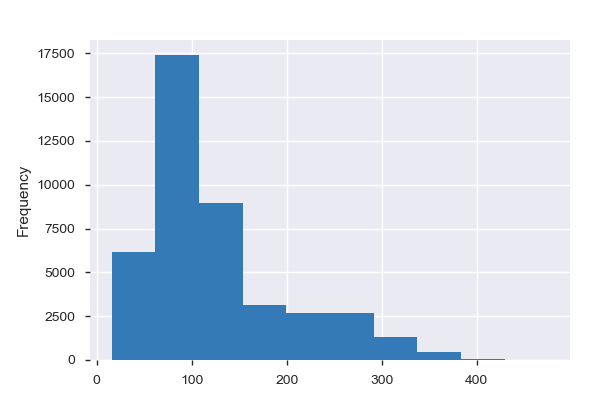

**Common Values**

| Value | Count | Frequency (%) |  |
| --- | --- | --- | --- |
| 70.0 | 571 | 1.3% |  |
| 75.0 | 564 | 1.3% |  |
| 65.0 | 529 | 1.2% |  |
| 73.0 | 511 | 1.2% |  |
| 77.0 | 509 | 1.2% |  |
| 68.0 | 500 | 1.1% |  |
| 67.0 | 499 | 1.1% |  |
| 69.0 | 496 | 1.1% |  |
| 72.0 | 491 | 1.1% |  |
| 76.0 | 474 | 1.1% |  |
| Other values (406) | 37639 | 85.6% |  |
| (Missing) | 1195 | 2.7% |  |

**Extreme Values**

Minimum 5 values

| Value | Count | Frequency (%) |  |
| --- | --- | --- | --- |
| 16.0 | 4 | 0.0% |  |
| 17.0 | 3 | 0.0% |  |
| 18.0 | 4 | 0.0% |  |
| 19.0 | 4 | 0.0% |  |
| 20.0 | 6 | 0.0% |  |

Maximum 5 values

| Value | Count | Frequency (%) |  |
| --- | --- | --- | --- |
| 440.0 | 1 | 0.0% |  |
| 442.0 | 1 | 0.0% |  |
| 443.0 | 1 | 0.0% |  |
| 451.0 | 1 | 0.0% |  |
| 475.0 | 1 | 0.0% |  |

AirTime  
Highly correlated

*This variable is highly correlated with `CRSElapsedTime` and should be ignored for analysis*

| Correlation | 0.98769 |
| --- | --- |

ArrDelay  
Numeric

| Distinct count | 332 |
| --- | --- |
| Unique (%) | 0.8% |
| Missing (%) | 2.7% |
| Missing (n) | 1195 |
| Infinite (%) | 0.0% |
| Infinite (n) | 0 |

| Mean | 9.3171 |
| --- | --- |
| Minimum | -63 |
| Maximum | 475 |
| Zeros (%) | 3.4% |

Toggle details

**Statistics**

Quantile statistics

| Minimum | -63 |
| --- | --- |
| 5-th percentile | -17 |
| Q1 | -6 |
| Median | 2 |
| Q3 | 14 |
| 95-th percentile | 61 |
| Maximum | 475 |
| Range | 538 |
| Interquartile range | 20 |

Descriptive statistics

| Standard deviation | 29.84 |
| --- | --- |
| Coef of variation | 3.2027 |
| Kurtosis | 26.857 |
| Mean | 9.3171 |
| MAD | 18.087 |
| Skewness | 3.9132 |
| Sum | 398610 |
| Variance | 890.44 |
| Memory size | 343.7 KiB |

**Histogram**

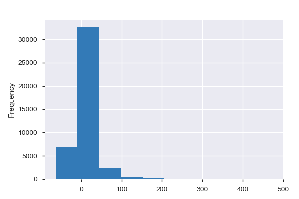

**Common Values**

| Value | Count | Frequency (%) |  |
| --- | --- | --- | --- |
| 0.0 | 1514 | 3.4% |  |
| -5.0 | 1407 | 3.2% |  |
| -2.0 | 1321 | 3.0% |  |
| -1.0 | 1317 | 3.0% |  |
| -3.0 | 1308 | 3.0% |  |
| -4.0 | 1299 | 3.0% |  |
| 1.0 | 1214 | 2.8% |  |
| 3.0 | 1202 | 2.7% |  |
| -6.0 | 1189 | 2.7% |  |
| -7.0 | 1170 | 2.7% |  |
| Other values (321) | 29842 | 67.9% |  |
| (Missing) | 1195 | 2.7% |  |

**Extreme Values**

Minimum 5 values

| Value | Count | Frequency (%) |  |
| --- | --- | --- | --- |
| -63.0 | 1 | 0.0% |  |
| -56.0 | 1 | 0.0% |  |
| -55.0 | 1 | 0.0% |  |
| -51.0 | 3 | 0.0% |  |
| -48.0 | 1 | 0.0% |  |

Maximum 5 values

| Value | Count | Frequency (%) |  |
| --- | --- | --- | --- |
| 399.0 | 1 | 0.0% |  |
| 410.0 | 1 | 0.0% |  |
| 460.0 | 1 | 0.0% |  |
| 470.0 | 1 | 0.0% |  |
| 475.0 | 1 | 0.0% |  |

ArrTime  
Numeric

| Distinct count | 1276 |
| --- | --- |
| Unique (%) | 2.9% |
| Missing (%) | 2.7% |
| Missing (n) | 1195 |
| Infinite (%) | 0.0% |
| Infinite (n) | 0 |

| Mean | 1504.6 |
| --- | --- |
| Minimum | 1 |
| Maximum | 2400 |
| Zeros (%) | 0.0% |

Toggle details

**Statistics**

Quantile statistics

| Minimum | 1 |
| --- | --- |
| 5-th percentile | 757 |
| Q1 | 1118 |
| Median | 1527 |
| Q3 | 1917 |
| 95-th percentile | 2230 |
| Maximum | 2400 |
| Range | 2399 |
| Interquartile range | 799 |

Descriptive statistics

| Standard deviation | 484.35 |
| --- | --- |
| Coef of variation | 0.3219 |
| Kurtosis | -0.56653 |
| Mean | 1504.6 |
| MAD | 410.32 |
| Skewness | -0.25185 |
| Sum | 64373000 |
| Variance | 234590 |
| Memory size | 343.7 KiB |

**Histogram**

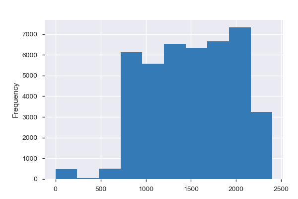

**Common Values**

| Value | Count | Frequency (%) |  |
| --- | --- | --- | --- |
| 1114.0 | 76 | 0.2% |  |
| 1900.0 | 76 | 0.2% |  |
| 1850.0 | 75 | 0.2% |  |
| 1834.0 | 75 | 0.2% |  |
| 1540.0 | 67 | 0.2% |  |
| 912.0 | 67 | 0.2% |  |
| 1446.0 | 66 | 0.2% |  |
| 1838.0 | 66 | 0.2% |  |
| 1950.0 | 66 | 0.2% |  |
| 1124.0 | 65 | 0.1% |  |
| Other values (1265) | 42084 | 95.7% |  |
| (Missing) | 1195 | 2.7% |  |

**Extreme Values**

Minimum 5 values

| Value | Count | Frequency (%) |  |
| --- | --- | --- | --- |
| 1.0 | 10 | 0.0% |  |
| 2.0 | 10 | 0.0% |  |
| 3.0 | 10 | 0.0% |  |
| 4.0 | 11 | 0.0% |  |
| 5.0 | 13 | 0.0% |  |

Maximum 5 values

| Value | Count | Frequency (%) |  |
| --- | --- | --- | --- |
| 2356.0 | 11 | 0.0% |  |
| 2357.0 | 13 | 0.0% |  |
| 2358.0 | 10 | 0.0% |  |
| 2359.0 | 10 | 0.0% |  |
| 2400.0 | 6 | 0.0% |  |

CRSArrTime  
Numeric

| Distinct count | 1041 |
| --- | --- |
| Unique (%) | 2.4% |
| Missing (%) | 0.0% |
| Missing (n) | 0 |
| Infinite (%) | 0.0% |
| Infinite (n) | 0 |

| Mean | 1485.3 |
| --- | --- |
| Minimum | 0 |
| Maximum | 2359 |
| Zeros (%) | 1.3% |

Toggle details

**Statistics**

Quantile statistics

| Minimum | 0 |
| --- | --- |
| 5-th percentile | 752 |
| Q1 | 1109 |
| Median | 1516 |
| Q3 | 1903 |
| 95-th percentile | 2223 |
| Maximum | 2359 |
| Range | 2359 |
| Interquartile range | 794 |

Descriptive statistics

| Standard deviation | 492.75 |
| --- | --- |
| Coef of variation | 0.33175 |
| Kurtosis | -0.29157 |
| Mean | 1485.3 |
| MAD | 413.73 |
| Skewness | -0.34735 |
| Sum | 65320047 |
| Variance | 242800 |
| Memory size | 343.7 KiB |

**Histogram**

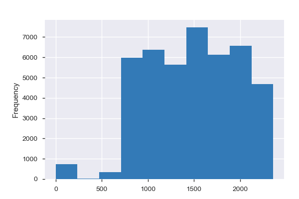

**Common Values**

| Value | Count | Frequency (%) |  |
| --- | --- | --- | --- |
| 0 | 569 | 1.3% |  |
| 1630 | 217 | 0.5% |  |
| 1725 | 190 | 0.4% |  |
| 1810 | 189 | 0.4% |  |
| 920 | 183 | 0.4% |  |
| 1555 | 175 | 0.4% |  |
| 1627 | 165 | 0.4% |  |
| 1505 | 162 | 0.4% |  |
| 1215 | 161 | 0.4% |  |
| 1900 | 160 | 0.4% |  |
| Other values (1031) | 41807 | 95.1% |  |

**Extreme Values**

Minimum 5 values

| Value | Count | Frequency (%) |  |
| --- | --- | --- | --- |
| 0 | 569 | 1.3% |  |
| 1 | 2 | 0.0% |  |
| 5 | 18 | 0.0% |  |
| 10 | 12 | 0.0% |  |
| 12 | 1 | 0.0% |  |

Maximum 5 values

| Value | Count | Frequency (%) |  |
| --- | --- | --- | --- |
| 2352 | 1 | 0.0% |  |
| 2353 | 21 | 0.0% |  |
| 2355 | 34 | 0.1% |  |
| 2357 | 1 | 0.0% |  |
| 2359 | 31 | 0.1% |  |

CRSDepTime  
Highly correlated

*This variable is highly correlated with `DepTime` and should be ignored for analysis*

| Correlation | 0.91498 |
| --- | --- |

CRSElapsedTime  
Highly correlated

*This variable is highly correlated with `ActualElapsedTime` and should be ignored for analysis*

| Correlation | 0.98409 |
| --- | --- |

CancellationCode  
Categorical

| Distinct count | 4 |
| --- | --- |
| Unique (%) | 0.0% |
| Missing (%) | 99.5% |
| Missing (n) | 43757 |

| B | 93 |
| --- | --- |
| A | 81 |
| C | 47 |
| (Missing) | 43757 |

Toggle details

| Value | Count | Frequency (%) |  |
| --- | --- | --- | --- |
| B | 93 | 0.2% |  |
| A | 81 | 0.2% |  |
| C | 47 | 0.1% |  |
| (Missing) | 43757 | 99.5% |  |

Cancelled  
Boolean

| Distinct count | 2 |
| --- | --- |
| Unique (%) | 0.0% |
| Missing (%) | 0.0% |
| Missing (n) | 0 |

| Mean | 0.024694 |
| --- | --- |

| 0 | 42892 |
| --- | --- |
| 1 | 1086 |

Toggle details

| Value | Count | Frequency (%) |  |
| --- | --- | --- | --- |
| 0 | 42892 | 97.5% |  |
| 1 | 1086 | 2.5% |  |

CarrierDelay  
Numeric

| Distinct count | 128 |
| --- | --- |
| Unique (%) | 0.3% |
| Missing (%) | 79.7% |
| Missing (n) | 35045 |
| Infinite (%) | 0.0% |
| Infinite (n) | 0 |

| Mean | 4.0478 |
| --- | --- |
| Minimum | 0 |
| Maximum | 369 |
| Zeros (%) | 16.7% |

Toggle details

**Statistics**

Quantile statistics

| Minimum | 0 |
| --- | --- |
| 5-th percentile | 0 |
| Q1 | 0 |
| Median | 0 |
| Q3 | 0 |
| 95-th percentile | 22 |
| Maximum | 369 |
| Range | 369 |
| Interquartile range | 0 |

Descriptive statistics

| Standard deviation | 16.206 |
| --- | --- |
| Coef of variation | 4.0036 |
| Kurtosis | 137.45 |
| Mean | 4.0478 |
| MAD | 6.7339 |
| Skewness | 9.6258 |
| Sum | 36159 |
| Variance | 262.63 |
| Memory size | 343.7 KiB |

**Histogram**

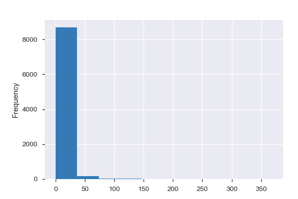

**Common Values**

| Value | Count | Frequency (%) |  |
| --- | --- | --- | --- |
| 0.0 | 7344 | 16.7% |  |
| 8.0 | 72 | 0.2% |  |
| 9.0 | 71 | 0.2% |  |
| 3.0 | 66 | 0.2% |  |
| 6.0 | 65 | 0.1% |  |
| 11.0 | 64 | 0.1% |  |
| 5.0 | 62 | 0.1% |  |
| 7.0 | 59 | 0.1% |  |
| 13.0 | 57 | 0.1% |  |
| 4.0 | 56 | 0.1% |  |
| Other values (117) | 1017 | 2.3% |  |
| (Missing) | 35045 | 79.7% |  |

**Extreme Values**

Minimum 5 values

| Value | Count | Frequency (%) |  |
| --- | --- | --- | --- |
| 0.0 | 7344 | 16.7% |  |
| 1.0 | 55 | 0.1% |  |
| 2.0 | 54 | 0.1% |  |
| 3.0 | 66 | 0.2% |  |
| 4.0 | 56 | 0.1% |  |

Maximum 5 values

| Value | Count | Frequency (%) |  |
| --- | --- | --- | --- |
| 277.0 | 1 | 0.0% |  |
| 282.0 | 1 | 0.0% |  |
| 285.0 | 1 | 0.0% |  |
| 354.0 | 1 | 0.0% |  |
| 369.0 | 1 | 0.0% |  |

DayOfWeek  
Numeric

| Distinct count | 7 |
| --- | --- |
| Unique (%) | 0.0% |
| Missing (%) | 0.0% |
| Missing (n) | 0 |
| Infinite (%) | 0.0% |
| Infinite (n) | 0 |

| Mean | 3.8206 |
| --- | --- |
| Minimum | 1 |
| Maximum | 7 |
| Zeros (%) | 0.0% |

Toggle details

**Statistics**

Quantile statistics

| Minimum | 1 |
| --- | --- |
| 5-th percentile | 1 |
| Q1 | 2 |
| Median | 4 |
| Q3 | 5 |
| 95-th percentile | 7 |
| Maximum | 7 |
| Range | 6 |
| Interquartile range | 3 |

Descriptive statistics

| Standard deviation | 1.905 |
| --- | --- |
| Coef of variation | 0.49861 |
| Kurtosis | -1.0826 |
| Mean | 3.8206 |
| MAD | 1.6113 |
| Skewness | 0.16787 |
| Sum | 168023 |
| Variance | 3.6291 |
| Memory size | 343.7 KiB |

**Histogram**

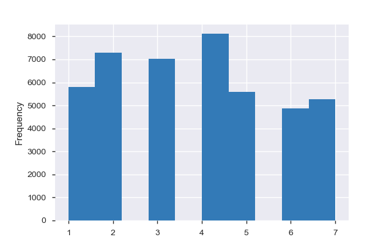

**Common Values**

| Value | Count | Frequency (%) |  |
| --- | --- | --- | --- |
| 4 | 8109 | 18.4% |  |
| 2 | 7303 | 16.6% |  |
| 3 | 7031 | 16.0% |  |
| 1 | 5802 | 13.2% |  |
| 5 | 5589 | 12.7% |  |
| 7 | 5277 | 12.0% |  |
| 6 | 4867 | 11.1% |  |

**Extreme Values**

Minimum 5 values

| Value | Count | Frequency (%) |  |
| --- | --- | --- | --- |
| 1 | 5802 | 13.2% |  |
| 2 | 7303 | 16.6% |  |
| 3 | 7031 | 16.0% |  |
| 4 | 8109 | 18.4% |  |
| 5 | 5589 | 12.7% |  |

Maximum 5 values

| Value | Count | Frequency (%) |  |
| --- | --- | --- | --- |
| 3 | 7031 | 16.0% |  |
| 4 | 8109 | 18.4% |  |
| 5 | 5589 | 12.7% |  |
| 6 | 4867 | 11.1% |  |
| 7 | 5277 | 12.0% |  |

DayofMonth  
Numeric

| Distinct count | 31 |
| --- | --- |
| Unique (%) | 0.1% |
| Missing (%) | 0.0% |
| Missing (n) | 0 |
| Infinite (%) | 0.0% |
| Infinite (n) | 0 |

| Mean | 14.601 |
| --- | --- |
| Minimum | 1 |
| Maximum | 31 |
| Zeros (%) | 0.0% |

Toggle details

**Statistics**

Quantile statistics

| Minimum | 1 |
| --- | --- |
| 5-th percentile | 2 |
| Q1 | 6 |
| Median | 14 |
| Q3 | 23 |
| 95-th percentile | 30 |
| Maximum | 31 |
| Range | 30 |
| Interquartile range | 17 |

Descriptive statistics

| Standard deviation | 9.1758 |
| --- | --- |
| Coef of variation | 0.62843 |
| Kurtosis | -1.2152 |
| Mean | 14.601 |
| MAD | 7.9695 |
| Skewness | 0.17157 |
| Sum | 642126 |
| Variance | 84.195 |
| Memory size | 343.7 KiB |

**Histogram**

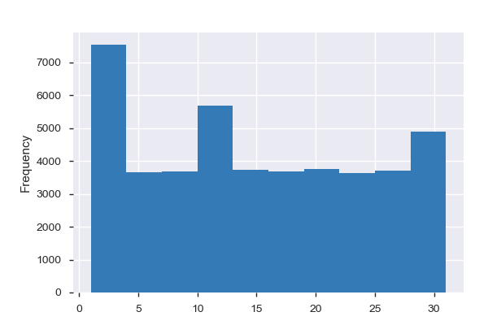

**Common Values**

| Value | Count | Frequency (%) |  |
| --- | --- | --- | --- |
| 3 | 3206 | 7.3% |  |
| 2 | 2960 | 6.7% |  |
| 11 | 2680 | 6.1% |  |
| 12 | 1800 | 4.1% |  |
| 1 | 1368 | 3.1% |  |
| 14 | 1262 | 2.9% |  |
| 19 | 1255 | 2.9% |  |
| 13 | 1253 | 2.8% |  |
| 21 | 1249 | 2.8% |  |
| 18 | 1247 | 2.8% |  |
| Other values (21) | 25698 | 58.4% |  |

**Extreme Values**

Minimum 5 values

| Value | Count | Frequency (%) |  |
| --- | --- | --- | --- |
| 1 | 1368 | 3.1% |  |
| 2 | 2960 | 6.7% |  |
| 3 | 3206 | 7.3% |  |
| 4 | 1215 | 2.8% |  |
| 5 | 1211 | 2.8% |  |

Maximum 5 values

| Value | Count | Frequency (%) |  |
| --- | --- | --- | --- |
| 27 | 1244 | 2.8% |  |
| 28 | 1247 | 2.8% |  |
| 29 | 1219 | 2.8% |  |
| 30 | 1208 | 2.7% |  |
| 31 | 1210 | 2.8% |  |

DepDelay  
Numeric

| Distinct count | 293 |
| --- | --- |
| Unique (%) | 0.7% |
| Missing (%) | 2.5% |
| Missing (n) | 1086 |
| Infinite (%) | 0.0% |
| Infinite (n) | 0 |

| Mean | 10.007 |
| --- | --- |
| Minimum | -16 |
| Maximum | 473 |
| Zeros (%) | 14.5% |

Toggle details

**Statistics**

Quantile statistics

| Minimum | -16 |
| --- | --- |
| 5-th percentile | -6 |
| Q1 | -2 |
| Median | 1 |
| Q3 | 10 |
| 95-th percentile | 56 |
| Maximum | 473 |
| Range | 489 |
| Interquartile range | 12 |

Descriptive statistics

| Standard deviation | 26.439 |
| --- | --- |
| Coef of variation | 2.6419 |
| Kurtosis | 36.094 |
| Mean | 10.007 |
| MAD | 14.993 |
| Skewness | 4.812 |
| Sum | 429240 |
| Variance | 699.01 |
| Memory size | 343.7 KiB |

**Histogram**

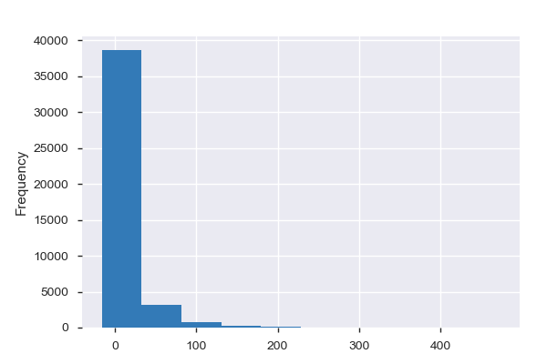

**Common Values**

| Value | Count | Frequency (%) |  |
| --- | --- | --- | --- |
| 0.0 | 6393 | 14.5% |  |
| -1.0 | 3749 | 8.5% |  |
| -2.0 | 3083 | 7.0% |  |
| 1.0 | 2425 | 5.5% |  |
| -3.0 | 2228 | 5.1% |  |
| -4.0 | 2014 | 4.6% |  |
| 2.0 | 1719 | 3.9% |  |
| 3.0 | 1355 | 3.1% |  |
| -5.0 | 1139 | 2.6% |  |
| 4.0 | 1124 | 2.6% |  |
| Other values (282) | 17663 | 40.2% |  |
| (Missing) | 1086 | 2.5% |  |

**Extreme Values**

Minimum 5 values

| Value | Count | Frequency (%) |  |
| --- | --- | --- | --- |
| -16.0 | 3 | 0.0% |  |
| -15.0 | 4 | 0.0% |  |
| -14.0 | 7 | 0.0% |  |
| -13.0 | 14 | 0.0% |  |
| -12.0 | 45 | 0.1% |  |

Maximum 5 values

| Value | Count | Frequency (%) |  |
| --- | --- | --- | --- |
| 381.0 | 1 | 0.0% |  |
| 384.0 | 1 | 0.0% |  |
| 396.0 | 1 | 0.0% |  |
| 458.0 | 1 | 0.0% |  |
| 473.0 | 1 | 0.0% |  |

DepTime  
Numeric

| Distinct count | 1144 |
| --- | --- |
| Unique (%) | 2.6% |
| Missing (%) | 2.5% |
| Missing (n) | 1086 |
| Infinite (%) | 0.0% |
| Infinite (n) | 0 |

| Mean | 1345.8 |
| --- | --- |
| Minimum | 1 |
| Maximum | 2400 |
| Zeros (%) | 0.0% |

Toggle details

**Statistics**

Quantile statistics

| Minimum | 1 |
| --- | --- |
| 5-th percentile | 649 |
| Q1 | 929 |
| Median | 1330 |
| Q3 | 1735 |
| 95-th percentile | 2103 |
| Maximum | 2400 |
| Range | 2399 |
| Interquartile range | 806 |

Descriptive statistics

| Standard deviation | 465.34 |
| --- | --- |
| Coef of variation | 0.34576 |
| Kurtosis | -1.1072 |
| Mean | 1345.8 |
| MAD | 400.83 |
| Skewness | 0.080993 |
| Sum | 57726000 |
| Variance | 216540 |
| Memory size | 343.7 KiB |

**Histogram**

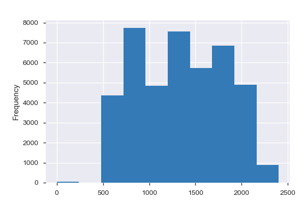

**Common Values**

| Value | Count | Frequency (%) |  |
| --- | --- | --- | --- |
| 700.0 | 235 | 0.5% |  |
| 800.0 | 155 | 0.4% |  |
| 630.0 | 137 | 0.3% |  |
| 659.0 | 135 | 0.3% |  |
| 715.0 | 126 | 0.3% |  |
| 1250.0 | 119 | 0.3% |  |
| 1740.0 | 113 | 0.3% |  |
| 1300.0 | 112 | 0.3% |  |
| 755.0 | 110 | 0.3% |  |
| 1420.0 | 110 | 0.3% |  |
| Other values (1133) | 41540 | 94.5% |  |
| (Missing) | 1086 | 2.5% |  |

**Extreme Values**

Minimum 5 values

| Value | Count | Frequency (%) |  |
| --- | --- | --- | --- |
| 1.0 | 4 | 0.0% |  |
| 4.0 | 1 | 0.0% |  |
| 5.0 | 1 | 0.0% |  |
| 8.0 | 1 | 0.0% |  |
| 10.0 | 2 | 0.0% |  |

Maximum 5 values

| Value | Count | Frequency (%) |  |
| --- | --- | --- | --- |
| 2356.0 | 10 | 0.0% |  |
| 2357.0 | 5 | 0.0% |  |
| 2358.0 | 1 | 0.0% |  |
| 2359.0 | 3 | 0.0% |  |
| 2400.0 | 4 | 0.0% |  |

Dest  
Categorical

| Distinct count | 134 |
| --- | --- |
| Unique (%) | 0.3% |
| Missing (%) | 0.0% |
| Missing (n) | 0 |

| PHX | 9317 |
| --- | --- |
| PHL | 4482 |
| PIT | 3020 |
| Other values (131) | 27159 |

Toggle details

| Value | Count | Frequency (%) |  |
| --- | --- | --- | --- |
| PHX | 9317 | 21.2% |  |
| PHL | 4482 | 10.2% |  |
| PIT | 3020 | 6.9% |  |
| ORD | 2103 | 4.8% |  |
| CLT | 1542 | 3.5% |  |
| DEN | 1470 | 3.3% |  |
| LAX | 1440 | 3.3% |  |
| SFO | 1331 | 3.0% |  |
| BOS | 831 | 1.9% |  |
| OAK | 808 | 1.8% |  |
| Other values (124) | 17634 | 40.1% |  |

Distance  
Highly correlated

*This variable is highly correlated with `AirTime` and should be ignored for analysis*

| Correlation | 0.97816 |
| --- | --- |

Diverted  
Boolean

| Distinct count | 2 |
| --- | --- |
| Unique (%) | 0.0% |
| Missing (%) | 0.0% |
| Missing (n) | 0 |

| Mean | 0.0024785 |
| --- | --- |

| 0 | 43869 |
| --- | --- |
| 1 | 109 |

Toggle details

| Value | Count | Frequency (%) |  |
| --- | --- | --- | --- |
| 0 | 43869 | 99.8% |  |
| 1 | 109 | 0.2% |  |

FlightNum  
Numeric

| Distinct count | 2439 |
| --- | --- |
| Unique (%) | 5.5% |
| Missing (%) | 0.0% |
| Missing (n) | 0 |
| Infinite (%) | 0.0% |
| Infinite (n) | 0 |

| Mean | 818.84 |
| --- | --- |
| Minimum | 1 |
| Maximum | 3949 |
| Zeros (%) | 0.0% |

Toggle details

**Statistics**

Quantile statistics

| Minimum | 1 |
| --- | --- |
| 5-th percentile | 55 |
| Q1 | 204 |
| Median | 557 |
| Q3 | 1242 |
| 95-th percentile | 2602 |
| Maximum | 3949 |
| Range | 3948 |
| Interquartile range | 1038 |

Descriptive statistics

| Standard deviation | 777.4 |
| --- | --- |
| Coef of variation | 0.94939 |
| Kurtosis | 0.89335 |
| Mean | 818.84 |
| MAD | 619.6 |
| Skewness | 1.2336 |
| Sum | 36011077 |
| Variance | 604360 |
| Memory size | 343.7 KiB |

**Histogram**

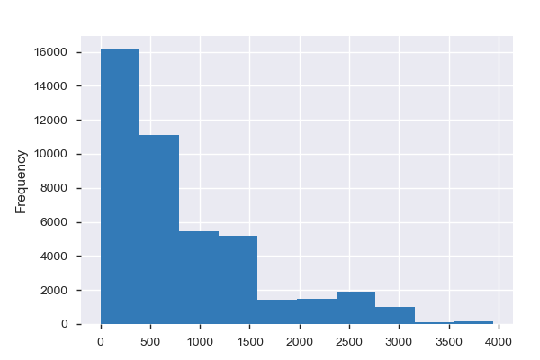

**Common Values**

| Value | Count | Frequency (%) |  |
| --- | --- | --- | --- |
| 55 | 245 | 0.6% |  |
| 93 | 210 | 0.5% |  |
| 58 | 206 | 0.5% |  |
| 76 | 197 | 0.4% |  |
| 80 | 155 | 0.4% |  |
| 98 | 155 | 0.4% |  |
| 39 | 154 | 0.4% |  |
| 86 | 154 | 0.4% |  |
| 34 | 152 | 0.3% |  |
| 159 | 152 | 0.3% |  |
| Other values (2429) | 42198 | 96.0% |  |

**Extreme Values**

Minimum 5 values

| Value | Count | Frequency (%) |  |
| --- | --- | --- | --- |
| 1 | 3 | 0.0% |  |
| 2 | 4 | 0.0% |  |
| 3 | 5 | 0.0% |  |
| 4 | 4 | 0.0% |  |
| 5 | 5 | 0.0% |  |

Maximum 5 values

| Value | Count | Frequency (%) |  |
| --- | --- | --- | --- |
| 3943 | 1 | 0.0% |  |
| 3946 | 1 | 0.0% |  |
| 3947 | 2 | 0.0% |  |
| 3948 | 3 | 0.0% |  |
| 3949 | 1 | 0.0% |  |

IsArrDelayed  
Categorical

| Distinct count | 2 |
| --- | --- |
| Unique (%) | 0.0% |
| Missing (%) | 0.0% |
| Missing (n) | 0 |

| YES | 24441 |
| --- | --- |
| NO | 19537 |

Toggle details

| Value | Count | Frequency (%) |  |
| --- | --- | --- | --- |
| YES | 24441 | 55.6% |  |
| NO | 19537 | 44.4% |  |

IsDepDelayed  
Categorical

| Distinct count | 2 |
| --- | --- |
| Unique (%) | 0.0% |
| Missing (%) | 0.0% |
| Missing (n) | 0 |

| YES | 23091 |
| --- | --- |
| NO | 20887 |

Toggle details

| Value | Count | Frequency (%) |  |
| --- | --- | --- | --- |
| YES | 23091 | 52.5% |  |
| NO | 20887 | 47.5% |  |

LateAircraftDelay  
Numeric

| Distinct count | 182 |
| --- | --- |
| Unique (%) | 0.4% |
| Missing (%) | 79.7% |
| Missing (n) | 35045 |
| Infinite (%) | 0.0% |
| Infinite (n) | 0 |

| Mean | 7.6201 |
| --- | --- |
| Minimum | 0 |
| Maximum | 373 |
| Zeros (%) | 16.2% |

Toggle details

**Statistics**

Quantile statistics

| Minimum | 0 |
| --- | --- |
| 5-th percentile | 0 |
| Q1 | 0 |
| Median | 0 |
| Q3 | 0 |
| 95-th percentile | 47.4 |
| Maximum | 373 |
| Range | 373 |
| Interquartile range | 0 |

Descriptive statistics

| Standard deviation | 23.488 |
| --- | --- |
| Coef of variation | 3.0823 |
| Kurtosis | 42.69 |
| Mean | 7.6201 |
| MAD | 12.346 |
| Skewness | 5.4563 |
| Sum | 68070 |
| Variance | 551.67 |
| Memory size | 343.7 KiB |

**Histogram**

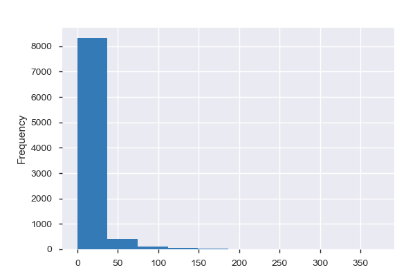

**Common Values**

| Value | Count | Frequency (%) |  |
| --- | --- | --- | --- |
| 0.0 | 7140 | 16.2% |  |
| 15.0 | 55 | 0.1% |  |
| 16.0 | 51 | 0.1% |  |
| 17.0 | 43 | 0.1% |  |
| 9.0 | 43 | 0.1% |  |
| 12.0 | 41 | 0.1% |  |
| 25.0 | 40 | 0.1% |  |
| 19.0 | 40 | 0.1% |  |
| 20.0 | 39 | 0.1% |  |
| 3.0 | 38 | 0.1% |  |
| Other values (171) | 1403 | 3.2% |  |
| (Missing) | 35045 | 79.7% |  |

**Extreme Values**

Minimum 5 values

| Value | Count | Frequency (%) |  |
| --- | --- | --- | --- |
| 0.0 | 7140 | 16.2% |  |
| 1.0 | 26 | 0.1% |  |
| 2.0 | 21 | 0.0% |  |
| 3.0 | 38 | 0.1% |  |
| 4.0 | 33 | 0.1% |  |

Maximum 5 values

| Value | Count | Frequency (%) |  |
| --- | --- | --- | --- |
| 263.0 | 1 | 0.0% |  |
| 292.0 | 1 | 0.0% |  |
| 309.0 | 1 | 0.0% |  |
| 343.0 | 1 | 0.0% |  |
| 373.0 | 1 | 0.0% |  |

Month  
Boolean

| Distinct count | 2 |
| --- | --- |
| Unique (%) | 0.0% |
| Missing (%) | 0.0% |
| Missing (n) | 0 |

| Mean | 1.4091 |
| --- | --- |

| 1 | 41979 |
| --- | --- |
| 10 | 1999 |

Toggle details

| Value | Count | Frequency (%) |  |
| --- | --- | --- | --- |
| 1 | 41979 | 95.5% |  |
| 10 | 1999 | 4.5% |  |

NASDelay  
Numeric

| Distinct count | 157 |
| --- | --- |
| Unique (%) | 0.4% |
| Missing (%) | 79.7% |
| Missing (n) | 35045 |
| Infinite (%) | 0.0% |
| Infinite (n) | 0 |

| Mean | 4.855 |
| --- | --- |
| Minimum | 0 |
| Maximum | 323 |
| Zeros (%) | 16.8% |

Toggle details

**Statistics**

Quantile statistics

| Minimum | 0 |
| --- | --- |
| 5-th percentile | 0 |
| Q1 | 0 |
| Median | 0 |
| Q3 | 0 |
| 95-th percentile | 28 |
| Maximum | 323 |
| Range | 323 |
| Interquartile range | 0 |

Descriptive statistics

| Standard deviation | 18.62 |
| --- | --- |
| Coef of variation | 3.8352 |
| Kurtosis | 71.086 |
| Mean | 4.855 |
| MAD | 8.1771 |
| Skewness | 7.1731 |
| Sum | 43370 |
| Variance | 346.7 |
| Memory size | 343.7 KiB |

**Histogram**

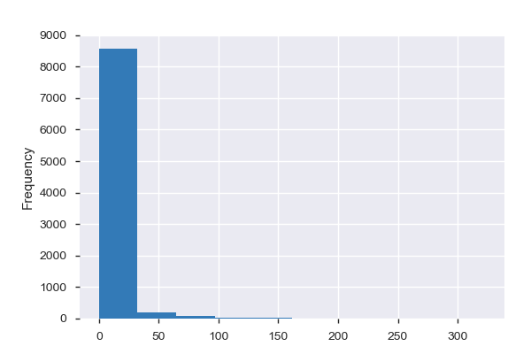

**Common Values**

| Value | Count | Frequency (%) |  |
| --- | --- | --- | --- |
| 0.0 | 7388 | 16.8% |  |
| 2.0 | 75 | 0.2% |  |
| 1.0 | 73 | 0.2% |  |
| 4.0 | 68 | 0.2% |  |
| 6.0 | 58 | 0.1% |  |
| 15.0 | 58 | 0.1% |  |
| 8.0 | 57 | 0.1% |  |
| 3.0 | 54 | 0.1% |  |
| 5.0 | 47 | 0.1% |  |
| 16.0 | 44 | 0.1% |  |
| Other values (146) | 1011 | 2.3% |  |
| (Missing) | 35045 | 79.7% |  |

**Extreme Values**

Minimum 5 values

| Value | Count | Frequency (%) |  |
| --- | --- | --- | --- |
| 0.0 | 7388 | 16.8% |  |
| 1.0 | 73 | 0.2% |  |
| 2.0 | 75 | 0.2% |  |
| 3.0 | 54 | 0.1% |  |
| 4.0 | 68 | 0.2% |  |

Maximum 5 values

| Value | Count | Frequency (%) |  |
| --- | --- | --- | --- |
| 269.0 | 1 | 0.0% |  |
| 285.0 | 1 | 0.0% |  |
| 293.0 | 1 | 0.0% |  |
| 307.0 | 1 | 0.0% |  |
| 323.0 | 1 | 0.0% |  |

Origin  
Categorical

| Distinct count | 132 |
| --- | --- |
| Unique (%) | 0.3% |
| Missing (%) | 0.0% |
| Missing (n) | 0 |

| DEN | 3558 |
| --- | --- |
| PIT | 3241 |
| ORD | 2246 |
| Other values (129) | 34933 |

Toggle details

| Value | Count | Frequency (%) |  |
| --- | --- | --- | --- |
| DEN | 3558 | 8.1% |  |
| PIT | 3241 | 7.4% |  |
| ORD | 2246 | 5.1% |  |
| BUR | 2021 | 4.6% |  |
| CLT | 1781 | 4.0% |  |
| PHL | 1632 | 3.7% |  |
| SFO | 1544 | 3.5% |  |
| LAX | 1268 | 2.9% |  |
| BWI | 996 | 2.3% |  |
| BOS | 976 | 2.2% |  |
| Other values (122) | 24715 | 56.2% |  |

SecurityDelay  
Numeric

| Distinct count | 13 |
| --- | --- |
| Unique (%) | 0.0% |
| Missing (%) | 79.7% |
| Missing (n) | 35045 |
| Infinite (%) | 0.0% |
| Infinite (n) | 0 |

| Mean | 0.017016 |
| --- | --- |
| Minimum | 0 |
| Maximum | 14 |
| Zeros (%) | 20.3% |

Toggle details

**Statistics**

Quantile statistics

| Minimum | 0 |
| --- | --- |
| 5-th percentile | 0 |
| Q1 | 0 |
| Median | 0 |
| Q3 | 0 |
| 95-th percentile | 0 |
| Maximum | 14 |
| Range | 14 |
| Interquartile range | 0 |

Descriptive statistics

| Standard deviation | 0.40394 |
| --- | --- |
| Coef of variation | 23.739 |
| Kurtosis | 721.18 |
| Mean | 0.017016 |
| MAD | 0.033959 |
| Skewness | 26.096 |
| Sum | 152 |
| Variance | 0.16317 |
| Memory size | 343.7 KiB |

**Histogram**

[7 more figures not shown]

Sample

|  | Year | Month | DayofMonth | DayOfWeek | DepTime | CRSDepTime | ArrTime | CRSArrTime | UniqueCarrier | FlightNum | TailNum | ActualElapsedTime | CRSElapsedTime | AirTime | ArrDelay | DepDelay | Origin | Dest | Distance | TaxiIn | TaxiOut | Cancelled | CancellationCode | Diverted | CarrierDelay | WeatherDelay | NASDelay | SecurityDelay | LateAircraftDelay | … |
| --- | --- | --- | --- | --- | --- | --- | --- | --- | --- | --- | --- | --- | --- | --- | --- | --- | --- | --- | --- | --- | --- | --- | --- | --- | --- | --- | --- | --- | --- | --- |
| 0 | 1987 | 10 | 14 | 3 | 741.0 | 730 | 912.0 | 849 | PS | 1451 | NaN | 91.0 | 79.0 | NaN | 23.0 | 11.0 | SAN | SFO | 447.0 | NaN | NaN | 0 | NaN | 0 | NaN | NaN | NaN | NaN | NaN | … |
| 1 | 1987 | 10 | 15 | 4 | 729.0 | 730 | 903.0 | 849 | PS | 1451 | NaN | 94.0 | 79.0 | NaN | 14.0 | -1.0 | SAN | SFO | 447.0 | NaN | NaN | 0 | NaN | 0 | NaN | NaN | NaN | NaN | NaN | … |
| 2 | 1987 | 10 | 17 | 6 | 741.0 | 730 | 918.0 | 849 | PS | 1451 | NaN | 97.0 | 79.0 | NaN | 29.0 | 11.0 | SAN | SFO | 447.0 | NaN | NaN | 0 | NaN | 0 | NaN | NaN | NaN | NaN | NaN | … |
| 3 | 1987 | 10 | 18 | 7 | 729.0 | 730 | 847.0 | 849 | PS | 1451 | NaN | 78.0 | 79.0 | NaN | -2.0 | -1.0 | SAN | SFO | 447.0 | NaN | NaN | 0 | NaN | 0 | NaN | NaN | NaN | NaN | NaN | … |
| 4 | 1987 | 10 | 19 | 1 | 749.0 | 730 | 922.0 | 849 | PS | 1451 | NaN | 93.0 | 79.0 | NaN | 33.0 | 19.0 | SAN | SFO | 447.0 | NaN | NaN | 0 | NaN | 0 | NaN | NaN | NaN | NaN | NaN | … |

```python
pandas_profiling.ProfileReport(airlines_df)
```

- Gather insights using exploratory methods, descriptive & inferential statistics
  - Find median, mode, std dev, min, max, average for each column. Do these make sense in the context of the column?
  - Do values have reasonable lower & upper bounds?
  - Univariate feature distributions (to observe stability & other patterns of a given feature like skew)
  - Feature & target correlations
  - Target analysis (plot of feature vs target)
  - Are there any outliers?
  - Do the column values seem to follow a normal distribution? Uniform? Exponential (i.e. long tail)?
  - Ensure correct data types are imputed
  - Look at the values. Ensure they make sense in the context of each column
  - Look for missing/empty values
  - Determine if there is a target imbalance? One class is represented less 15% of the outcomes.
  - For categorical fields, what are the unique values in the field?
  - For numeric fields, are all values numbers?

```python
profile = pandas_profiling.ProfileReport(airlines_df)
profile.to_file(outputfile="../data/processed/data_analysis.html")
```

When we are building machine learning models, several learners are sensitive to features which are highly correlated. In other words, including features with high correlations reduces the predictive power of the model. `pandas-profiling` can automatically retrieve the list of variables which are rejected due to high correlations...

```python
profile = pandas_profiling.ProfileReport(airlines_df)
rejected_variables = profile.get_rejected_variables(threshold=0.9)
rejected_variables
```

[output not shown]

It's of no surprise that **Scheduled Elapsed Time** is positively correlated to **Distance** as further distances take longer time to travel; thus resulting in longer time spent in the air.

### Business Analysis

Before a model is released into production, we must understand how the outputs of the machine learning model **impact the business objectives**. One way to assess the impact to the business objective is to define the cost of errors (bad predictions). In the case of a binary classifier, the two types of errors which can result are **Type 1 (False Positive)** and **Type 2 (False Negative)**.

Consider the following confusion matrix for the airline dataset we've been using in this course...

[figure not shown]

Let's refer to the test set confusion matrix which resulted from the model development process covered earlier.

```
Confusion Matrix...
[[3768 3178]
 [2009 5558]]
```

[output not shown]

One approach to evaluating the business result of the predictions from this model is using the following formula:

`Business Impact = Revenue * TP + Revenue * TN - Cost * FP - Cost * FN`

```python
business_impact = 700 * 3768 + 700 * 5558 - 3178 * 500 - 2009 * 100
business_impact
```

```
4738300
```

This model will result in a net positive value of $4,738,300 if we assume a single passenger was to travel on every flight in our test set.